# Geographically Weighted Regression -- A case study of second-hand housing prices in Qinhuai District, Nanjing

**Course**: Spatial Analysis and Modeling (SE, 856.142)

**Authors**: Boqin Cai (boqin.cai@stud.sbg.ac.at)

[figure not shown]

## Introduction

Geographically Weighted Regression (GWR) is one of several spatial regression techniques used in geography and other disciplines. GWR evaluates a local model of the variable or process you are trying to understand or predict by fitting a regression equation to every feature in the dataset. GWR constructs these separate equations by incorporating the dependent and explanatory variables of the features falling within the neighborhood of each target feature. The shape and extent of each neighborhood analyzed is based on the Neighborhood Type and Neighborhood Selection Method parameters. GWR should be applied to datasets with several hundred features. It is not an appropriate method for small datasets and does not work with multipoint data.

[figure not shown]

References:

1. [How Geographically Weighted Regression (GWR) works](https://pro.arcgis.com/en/pro-app/tool-reference/spatial-statistics/how-geographicallyweightedregression-works.htm)

Sources:

1. https://pro.arcgis.com/en/pro-app/tool-reference/spatial-statistics/geographicallyweightedregression.htm

## Models

- Linear Regression（Ordinary Least Squares）
- Geographically Weighted Regression (GWR)
- Multiscale Geographically Weighted Regression (MGWR)

### Linear Regression（Ordinary Least Squares）

In statistics, linear regression is a linear approach to modeling the relationship between a scalar response (or dependent variable) and one or more explanatory variables (or independent variables).

[figure not shown]

(Source: https://en.wikipedia.org/wiki/Linear_regression)

A global regression model written as:

$y_i = \beta_0 + \sum_k{\beta_kx_{ik}} + \varepsilon_i$

where $\beta$ is the regression coefficients and the $\varepsilon_i$ represents the error term or noise in the model.

**References**:

1. [Linear regression --Wikipedia](https://en.wikipedia.org/wiki/Linear_regression)

### Geographically Weighted Regression (GWR)

[figure not shown]

GWR extends this traditional regression framework by allowing local rather than global parameters to be estimated so that the model is rewritten as:

$y_i = \beta_0(u_i, v_i) + \sum_k{\beta_k(u_i, v_i)x_{ik}} + \varepsilon_i$

where $(u_i,v_i)$ denotes the coordinates of the $i$th point in space and $\beta_k(u_i,v_i)$ is a realisation of the continuous function $\beta_k(u, v)$ at point $i$.

**References**:

1. [Spatial analysis Spatial regression -- Wikipedia](https://en.wikipedia.org/wiki/Spatial_analysis#Spatial_regression)
2. Fotheringham, A. Stewart, Chris Brunsdon, and Martin Charlton. Geographically weighted regression: the analysis of spatially varying relationships. John Wiley & Sons, 2003.

### Multiscale Geographically Weighted Regression (MGWR)

Whereas both GWR constrain the local relationships within each model to vary at the same spatial scale, MGWR allows the conditional relationships between the response variable and the different predictor variables to vary at different spatial scales. That is, the **bandwidths** indicating the data-borrowing range can vary across parameter surfaces.

$y_i = \beta_{bw0}(u_i, v_i) + \sum_k{\beta_{bwk}(u_i, v_i)x_{ik}} + \varepsilon_i$

where $bwk$ in $\beta_{bwk}$ indicates the bandwidth used for calibration of the $k$th conditional relationship.

ArcGIS doesn't support the MGWR model so far. In this case, I use the MGWR model in pysal module to apply this method on my dataset.

**References**:

1. Fotheringham, A. Stewart, Wenbai Yang, and Wei Kang. "Multiscale geographically weighted regression (MGWR)." Annals of the American Association of Geographers 107.6 (2017): 1247-1265.

## GWR in ArcGIS

GWR has been included in ArcGIS software, which can be found in spatial statistics tools. The GWR tool provides a local model of the variable or process you are trying to understand or predict by fitting a regression equation to every feature in the dataset.

The following picture is the interface of the tool.

[figure not shown]

### Key parameters and explanations

| Parameter | Explanation |
| --- | --- |
| model_type | Specifies the type of data that will be modeled. **CONTINUOUS** — The dependent_variable is continuous. The Gaussian model will be used, and the tool will perform ordinary least squares regression. **… |
| neighborhood_type | Specifies whether the neighborhood used is constructed as a fixed distance or allowed to vary in spatial extent depending on the density of the features. **NUMBER_OF_NEIGHBORS** — The neighborhood siz… |
| neighborhood_selection_method | Specifies how the neighborhood size will be determined. The neighborhood selected with the OPTIMIZED and MANUAL_INTERVALS options is based on minimizing the Akaike Information Criterion (AICc) value. … |
| minimum_number_of_neighbors(Optional) | The minimum number of neighbors each feature must include in its calculations. It is suggested to use at least 30 neighbors. |
| maximum_number_of_neighbors(Optional) | The maximum number of neighbors (up to 1000) each feature includes in its calculations. |
| minimum_search_distance(Optional) | The minimum neighborhood search distance. It is suggested to use a distance at which each feature has at least 30 neighbors. |
| maximum_search_distance(Optional) | The maximum neighborhood search distance. If a distance results in features with more than 1000 neighbors, the tool will use the first 1000 in calculations for the target feature. |
| local_weighting_scheme(Optional) | Specifies the kernel type that will be used to provide the spatial weighting in the model. The kernel defines how each feature is related to other features within its neighborhood. **BISQUARE** —A wei… |

(Source: https://pro.arcgis.com/en/pro-app/tool-reference/spatial-statistics/geographicallyweightedregression.htm)

### Neighborhood type

[figure not shown]

### Kernel type

[figure not shown]

The red line is **GAUSSIAN** kernel and the blue line is **BISQUARE** kernel.

## Research Area

Qinhuai district in Nanjing

```python
from ipyleaflet import Map, GeoData, basemaps, LayersControl
import geopandas
import warnings
warnings.filterwarnings('ignore')

researchArea = geopandas.read_file('qinhuai_polygon.shp')

m = Map(center=(32.012,118.815), zoom = 12, basemap= basemaps.Esri.WorldImagery)

geo_data = GeoData(geo_dataframe = researchArea.to_crs(4326),
                   style={'color': 'black', 'fillColor': '#3366cc', 'opacity':0.05\
                          , 'weight':1.9, 'dashArray':'2', 'fillOpacity':0.6},
                   hover_style={'fillColor': 'red' , 'fillOpacity': 0.2},
                   name = 'Qinhuai')

m.add_layer(geo_data)
m.add_control(LayersControl())

m
```

## Data Description

The second-hand housing prices data is collected from website and preprocessed before. The data has 2324 raws which represents 2324 details of the second-hand house. There are 7 columns including 3 spatial relationships with the bus stops. The following figure shows what the spatial relationships are.

[figure not shown]

The column name and the description are written below.

| Column names | Descriptions |
| --- | --- |
| total | The total price of the house |
| unit | The unit price of the house (CNY/$m^2$) |
| area | The area of the house ($m^2$) |
| age_of_hou | The age of the house (2020 - Year of Construction) |
| dis_bussto | The distance to the nearest bus stop (m) |
| busstop_nu | The number of the bus stop within 500m |
| dis_conf_t | The distance to Confucius Temple |

Because the total price is the multiply of the unit price and area, I just remove it during the analysis. The unit price is the dependent variable and the following 5 are considered as explanatory variables.

### Data preprocessing

Fill the missing value with the mean value of the colomn.

### Data exploration

Visualize the distribution of data and check the outliers. The histogram plot and box plot are used.

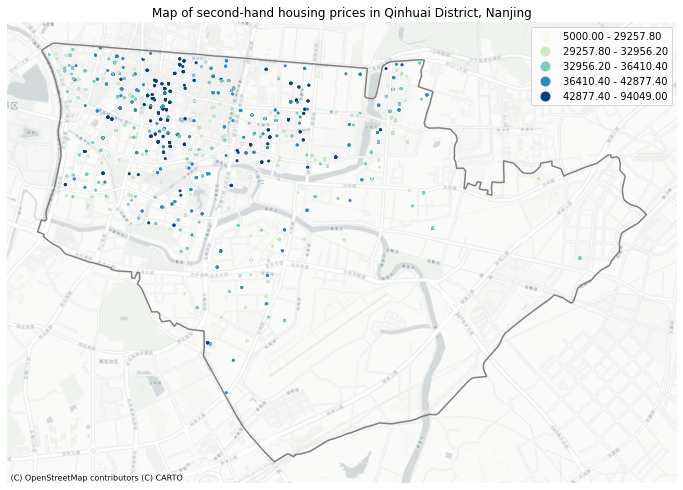

```python
drawMapNanjing(df, 'unit', title='Map of second-hand housing prices in Qinhuai District, Nanjing')
```

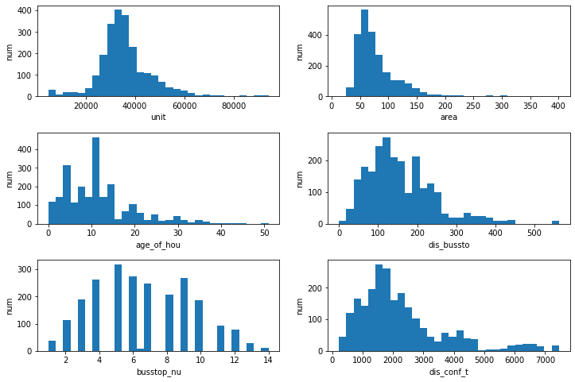

```python
### Histogram

fig = plt.figure(figsize = (12, 8))

for index, key in enumerate(keys):
    ax = fig.add_subplot(321+index)
    ax.hist(df[key], bins=30)
    ax.set_xlabel(key)
    ax.set_ylabel('num')

plt.subplots_adjust(hspace =0.4)
plt.show()
```

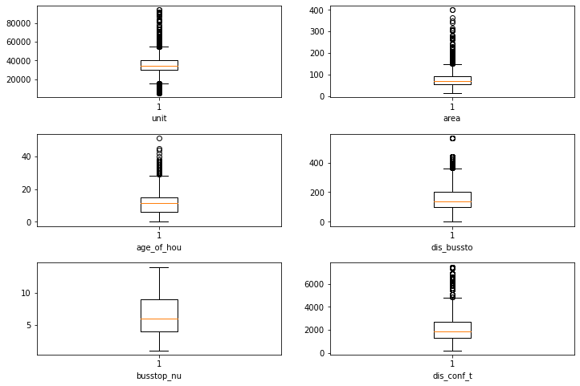

```python
fig = plt.figure(figsize = (12, 8))

for index, key in enumerate(keys):
    ax = fig.add_subplot(321+index)
    ax.boxplot(df[key])
    ax.set_xlabel(key)

plt.subplots_adjust(hspace =0.4)
plt.show()
```

### Multicollinearity

In global regression models, results are unreliable when two or more variables exhibit multicollinearity (when two or more variables are redundant or together tell the same story).

[figure not shown]

Corralation coefficient and variance inflation factor (VIF)

$COR(X,Y)=\frac{\sum_{i}{(X_i-\bar{X})(Y_i-\bar{Y})}}{\sqrt{\sum_i{(X_i-\bar{X})^2}\sum_{i}{(Y_i-\bar{Y})^2}}}$

$VIF=1/{(1-COR(X,Y)^2)}$

References:

1. [How Geographically Weighted Regression (GWR) works](https://pro.arcgis.com/en/pro-app/tool-reference/spatial-statistics/how-geographicallyweightedregression-works.htm)

(Image source: https://medium.com/@mackenziemitchell6/multicollinearity-6efc5902702)

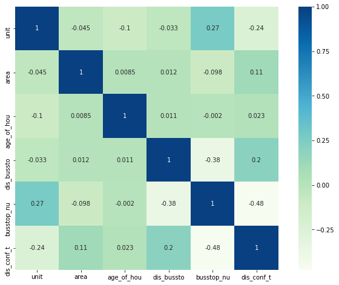

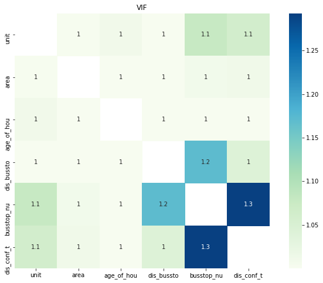

```python
X=df.iloc[:,3:9]
X_corrmat=X.corr()
vif=1/(1-X_corrmat**2)
vif.values[vif.values==np.inf]=np.nan # Inf to nan
f,ax=plt.subplots(figsize=(12,8))
sns.heatmap(X_corrmat,square=True,annot=True, cmap='GnBu')
# plt.title("Correlation Coefficient Matrix")
plt.show()

f,ax=plt.subplots(figsize=(12,8))
sns.heatmap(vif,square=True,annot=True, cmap='GnBu')
plt.title("VIF")
plt.show()
```

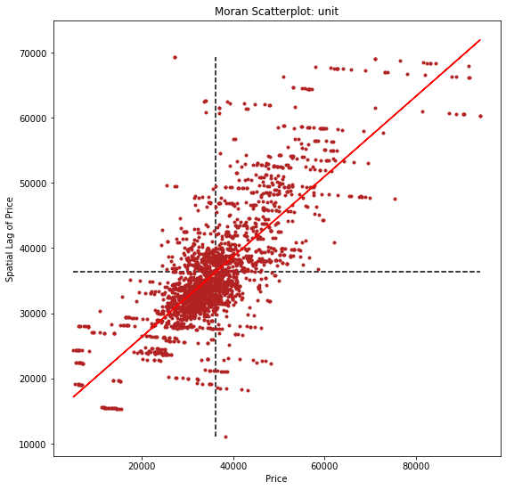

```
Moran's I: 0.6150178430899614
```

```python
globalMoransI(df, 'unit')
```

## Linear regression (Ordinary least squares) in Python

Statsmodels is a Python module that provides classes and functions for the estimation of many different statistical models, as well as for conducting statistical tests, and statistical data exploration. An extensive list of result statistics are available for each estimator.

👉 [Statsmodels webpage](https://www.statsmodels.org/stable/index.html)

```python
import statsmodels.api as sm

X=df.iloc[:,4:9]
X=sm.add_constant(X)
model=sm.OLS(df['unit'], X).fit()

print(model.summary())
```

```
                            OLS Regression Results
==============================================================================
Dep. Variable:                   unit   R-squared:                       0.105
Model:                            OLS   Adj. R-squared:                  0.103
Method:                 Least Squares   F-statistic:                     54.60
Date:                Mon, 25 May 2020   Prob (F-statistic):           9.35e-54
Time:                        23:48:46   Log-Likelihood:                -24816.
No. Observations:                2324   AIC:                         4.964e+04
Df Residuals:                    2318   BIC:                         4.968e+04
Df Model:                           5
Covariance Type:            nonrobust
==============================================================================
                 coef    std err          t      P>|t|      [0.025      0.975]
------------------------------------------------------------------------------
const       3.273e+04   1197.089     27.341      0.000    3.04e+04    3.51e+04
area          -2.0040      5.480     -0.366      0.715     -12.749       8.741
age_of_hou  -142.3754     28.097     -5.067      0.000    -197.474     -87.277
dis_bussto    11.1981      2.747      4.076      0.000       5.811      16.586
busstop_nu   908.1371     92.704      9.796      0.000     726.345    1089.929
dis_conf_t    -1.1185      0.172     -6.492      0.000      -1.456      -0.781
==============================================================================
Omnibus:                      468.812   Durbin-Watson:                   1.176
Prob(Omnibus):                  0.000   Jarque-Bera (JB):             2338.828
Skew:                           0.869   Prob(JB):                         0.00
Kurtosis:                       7.597   Cond. No.                     1.48e+04
==============================================================================

Warnings:
[1] Standard Errors assume that the covariance matrix of the errors is correctly specified.
[2] The condition number is large, 1.48e+04. This might indicate that there are
strong multicollinearity or other numerical problems.
```

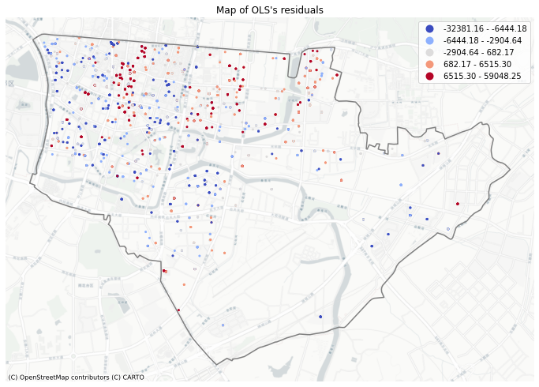

```python
df['OLS_residuals']=model.resid

drawMapNanjing(df, 'OLS_residuals', 'coolwarm', "Map of OLS's residuals")
```

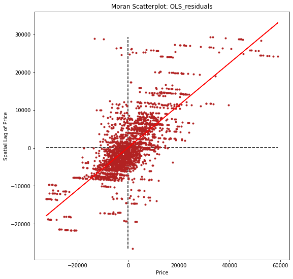

```
Moran's I: 0.5565651590056987
```

```python
globalMoransI(df, 'OLS_residuals')
```

## Process in ArcGIS Pro

Launch ArcGIS Pro, load the data and open the GWR interface.

[figure not shown]

So in this case,

- Model type is Continuous(Gaussian)
- Neighborhood type is Number of neighbors
- Neighborhood Selection Method is Golden search
- The kernel type(Local weighting scheme) is Gaussian

After setting that click run button.

### Result output

The out put information has 3 parts. The model diagnosis, the vector layer and the raster layers.

#### Messages from ArcGIS Pro log window

```
--- Golden Search Results ---
Number of Neighbors       AICc
30                  47365.8504
1000                49307.2542
401                 49135.0477
629                 49234.8761
259                 48991.2987
172                 48813.2592
117                 48589.4127
84                  48336.4056
63                  48095.9433
51                  47898.3082
43                  47767.8478
38                  47624.2293
35                  47495.2182
33                  47424.8429
32                  47415.2282
31                  47369.0500
-----------------------------
-------- Analysis Details -------
Number of Features:           2324
Dependent Variable:           UNIT
Explanatory Variables:        AREA
                        AGE_OF_HOU
                        DIS_BUSSTO
                        BUSSTOP_NU
                        DIS_CONF_T
Number of Neighbors:            31
---------------------------------

------------ Model Diagnostics ------------
R2:                                   0.7152
AdjR2:                                0.6826
AICc:                             47369.0500
Sigma-Squared:                 39122376.6094
Sigma-Squared MLE:             35098825.1953
Effective Degrees of Freedom:      2084.9876
-------------------------------------------
Completed script Geographically Weighted Regression (GWR)...
```

#### Vector layer

After running, the model output a vector layer which includes fields for observed and predicted y values, condition number (cond), Local R2, explanatory variable coefficients, and standard errors.

[figure not shown]

The following output is the dataset of this vector feature class.

```python
from IPython.display import display
pd.options.display.max_columns = None

result_of_arcgis=geopandas.read_file('/Users/caiboqin/Documents/ArcGIS/Projects/MyProject1/GWR_ArcGIS_Output.shp')
display(result_of_arcgis)
```

|  | SOURCE_ID | unit | area | age_of_hou | dis_bussto | busstop_nu | dis_conf_t | INTRCPT | SE_INTRCPT | C_AREA | SE_AREA | C_AGE_OF_H | SE_AGE_OF_ | C_DIS_BUSS | SE_DIS_BUS | C_BUSSTOP_ | SE_BUSSTOP | C_DIS_CONF | SE_DIS_CON | PREDICTED | RESIDUAL | STDRESID | INFLUENCE | COOKS_D | CND_NUMBER | LOCALR2 | geometry |
| --- | --- | --- | --- | --- | --- | --- | --- | --- | --- | --- | --- | --- | --- | --- | --- | --- | --- | --- | --- | --- | --- | --- | --- | --- | --- | --- | --- |
| 0 | 0 | 34508.0 | 68.10 | 27.0 | 137.450453 | 13.0 | 2187.065311 | 41039.231473 | 2628.237601 | 69.177184 | 12.721698 | 54.318963 | 66.469024 | 1.578079 | 7.713031 | -1018.065303 | 240.361807 | -1.303159 | 1.052582 | 31348.774071 | 3159.225928 | 0.526102 | 0.078286 | 1.291905e-04 | 10950.273467 | 0.683371 | POINT (383379.732 3546196.909) |
| 1 | 1 | 34412.0 | 68.00 | 28.0 | 137.450453 | 13.0 | 2187.065311 | 41039.231473 | 2628.237601 | 69.177184 | 12.721698 | 54.318963 | 66.469024 | 1.578079 | 7.713031 | -1018.065303 | 240.361807 | -1.303159 | 1.052582 | 31396.175316 | 3015.824684 | 0.503549 | 0.083138 | 1.263521e-04 | 10950.273467 | 0.683371 | POINT (383379.732 3546196.909) |
| 2 | 2 | 31342.0 | 30.63 | 31.0 | 137.450453 | 13.0 | 2187.065311 | 41039.231473 | 2628.237601 | 69.177184 | 12.721698 | 54.318963 | 66.469024 | 1.578079 | 7.713031 | -1018.065303 | 240.361807 | -1.303159 | 1.052582 | 28973.980847 | 2368.019153 | 0.401457 | 0.110662 | 1.102080e-04 | 10950.273467 | 0.683371 | POINT (383379.732 3546196.909) |
| 3 | 3 | 31015.0 | 30.63 | 31.0 | 137.450453 | 13.0 | 2187.065311 | 41039.231473 | 2628.237601 | 69.177184 | 12.721698 | 54.318963 | 66.469024 | 1.578079 | 7.713031 | -1018.065303 | 240.361807 | -1.303159 | 1.052582 | 28973.980847 | 2041.019153 | 0.346020 | 0.110662 | 8.187230e-05 | 10950.273467 | 0.683371 | POINT (383379.732 3546196.909) |
| 4 | 4 | 31255.0 | 61.43 | 32.0 | 137.450453 | 13.0 | 2187.065311 | 41039.231473 | 2628.237601 | 69.177184 | 12.721698 | 54.318963 | 66.469024 | 1.578079 | 7.713031 | -1018.065303 | 240.361807 | -1.303159 | 1.052582 | 31158.957072 | 96.042929 | 0.016244 | 0.106441 | 1.727305e-07 | 10950.273467 | 0.683371 | POINT (383379.732 3546196.909) |
| ... | ... | ... | ... | ... | ... | ... | ... | ... | ... | ... | ... | ... | ... | ... | ... | ... | ... | ... | ... | ... | ... | ... | ... | ... | ... | ... | ... |
| 2319 | 2319 | 29754.0 | 61.84 | 0.0 | 149.618626 | 2.0 | 4337.704464 | 25635.307643 | 4582.256178 | 70.533913 | 14.814728 | -93.085699 | 65.051836 | 1.624819 | 7.266063 | 857.897011 | 403.296207 | -0.598602 | 0.881539 | 29359.462883 | 394.537117 | 0.064890 | 0.055076 | 1.348721e-06 | 59947.148377 | 0.521948 | POINT (389591.061 3544759.058) |
| 2320 | 2320 | 30406.0 | 61.83 | 0.0 | 44.958496 | 3.0 | 4225.084225 | 21465.597325 | 6133.814079 | 78.773581 | 17.934847 | -79.406354 | 79.250396 | 1.007146 | 8.188292 | 905.267864 | 454.056195 | 0.183585 | 1.305593 | 29872.912728 | 533.087272 | 0.090414 | 0.111411 | 5.632464e-06 | 106744.692504 | 0.495213 | POINT (389479.192 3544773.223) |
| 2321 | 2321 | 28571.0 | 63.00 | 0.0 | 116.422392 | 4.0 | 5088.735613 | 32446.396196 | 3356.881426 | 58.467399 | 16.610550 | -135.732508 | 64.386587 | 3.962053 | 6.535366 | 1054.106651 | 372.579175 | -2.116420 | 0.458047 | 30037.636938 | -1466.636938 | -0.241060 | 0.053831 | 1.816857e-05 | 36382.423037 | 0.594763 | POINT (390339.378 3544694.942) |
| 2322 | 2322 | 27726.0 | 59.51 | 0.0 | 149.618626 | 2.0 | 4337.704464 | 25635.307643 | 4582.256178 | 70.533913 | 14.814728 | -93.085699 | 65.051836 | 1.624819 | 7.266063 | 857.897011 | 403.296207 | -0.598602 | 0.881539 | 29195.118867 | -1469.118867 | -0.241717 | 0.055778 | 1.896723e-05 | 59947.148377 | 0.521948 | POINT (389591.061 3544759.058) |
| 2323 | 2323 | 27613.0 | 62.29 | 0.0 | 149.618626 | 2.0 | 4337.704464 | 25635.307643 | 4582.256178 | 70.533913 | 14.814728 | -93.085699 | 65.051836 | 1.624819 | 7.266063 | 857.897011 | 403.296207 | -0.598602 | 0.881539 | 29391.203144 | -1778.203144 | -0.292445 | 0.054961 | 2.733359e-05 | 59947.148377 | 0.521948 | POINT (389591.061 3544759.058) |

2324 rows × 27 columns

Run the Spatial Autocorrelation (Moran's I) tool on the regression residuals to ensure that they are spatially random.

The Spatial Autocorrelation result is shown below:

```
Running script SpatialAutocorrelation...
Global Moran's I Summary
Moran's Index:   0.103482
Expected Index:  -0.000430
Variance:        0.000037
z-score:         17.011874
p-value:         0.000000
Completed script Spatial Autocorrelation (Global Moran's I)...
```

**References**:

1. [Interpreting GWR results](https://desktop.arcgis.com/en/arcmap/latest/tools/spatial-statistics-toolbox/interpreting-gwr-results.htm)

#### Raster layers

The raster layers indicate the coefficient raster surfaces created by GWR to better understand regional variation in the model explanatory variables.

[figure not shown]

## GWR in Python

PySAL is an open-source project designed to support spatial data science, which is written in Python. It provides lots of models for spatial data science including spatial autocorrelation, GWR, etc.

👉 [Pysal webpage](https://pysal.org/)

```python
gwr_selector = Sel_BW(g_coords, g_y, g_X, kernel='gaussian')
gwr_bw = gwr_selector.search(criterion='AICc', search_method='golden_section')
print('Bandwidth: ', gwr_bw)
gwr_results = GWR(g_coords, g_y, g_X, gwr_bw).fit()
```

```
Bandwidth:  53.0
```

**Note**:

| Variable | Label |
| --- | --- |
| X0 | const |
| X1 | area |
| X2 | age_of_hou |
| X3 | dis_bussto |
| X4 | busstop_nu |
| X5 | dis_conf_t |

```python
print(gwr_results.summary())
```

```
===========================================================================
Model type                                                         Gaussian
Number of observations:                                                2324
Number of covariates:                                                     6

Global Regression Results
---------------------------------------------------------------------------
Residual sum of squares:                                       256250595551.252
Log-likelihood:                                                  -24815.967
AIC:                                                              49643.933
AICc:                                                             49645.982
BIC:                                                           256250577584.329
R2:                                                                   0.105
Adj. R2:                                                              0.103

Variable                              Est.         SE  t(Est/SE)    p-value
------------------------------- ---------- ---------- ---------- ----------
X0                               32729.008   1197.089     27.341      0.000
X1                                  -2.004      5.480     -0.366      0.715
X2                                -142.375     28.097     -5.067      0.000
X3                                  11.198      2.747      4.076      0.000
X4                                 908.137     92.704      9.796      0.000
X5                                  -1.119      0.172     -6.492      0.000

Geographically Weighted Regression (GWR) Results
---------------------------------------------------------------------------
Spatial kernel:                                           Adaptive bisquare
Bandwidth used:                                                      53.000

Diagnostic information
---------------------------------------------------------------------------
Residual sum of squares:                                       38517550484.362
Effective number of parameters (trace(S)):                          464.948
Degree of freedom (n - trace(S)):                                  1859.052
Sigma estimate:                                                    4551.804
Log-likelihood:                                                  -22613.928
AIC:                                                              46159.752
AICc:                                                             46394.073
BIC:                                                              48839.439
R2:                                                                   0.866
Adjusted R2:                                                          0.832
Adj. alpha (95%):                                                     0.001
Adj. critical t value (95%):                                          3.416

Summary Statistics For GWR Parameter Estimates
---------------------------------------------------------------------------
Variable                   Mean        STD        Min     Median        Max
-------------------- ---------- ---------- ---------- ---------- ----------
X0                    16227.046 174567.177 -1641632.861  33170.990 293431.416
X1                      -22.863    104.452   -495.495    -15.512    273.476
X2                       13.907    366.609  -1428.627    -22.181   3595.810
X3                       15.668    125.496   -437.839      1.315    791.960
X4                      613.082   5590.806 -22367.054    350.075  28554.496
X5                        8.300     74.213   -125.870     -0.650    596.836
===========================================================================

None
```

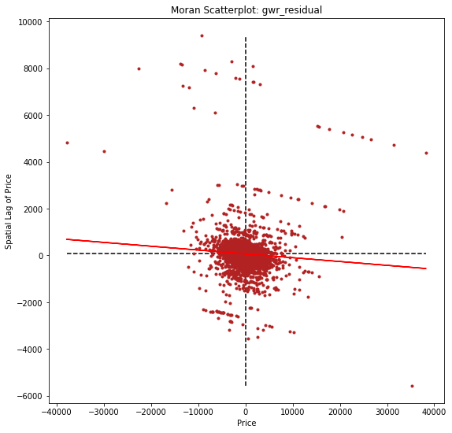

```
Moran's I: -0.016366296650593106
```

```python
df['gwr_residual']=gwr_results.resid_response
globalMoransI(df, 'gwr_residual')
```

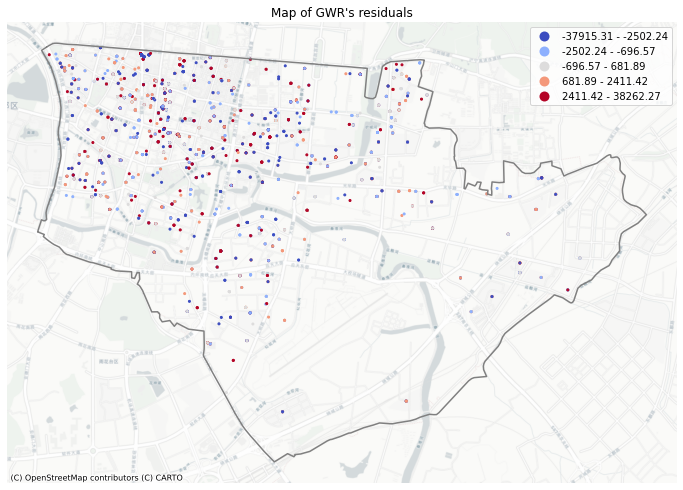

```python
drawMapNanjing(df, 'gwr_residual', 'coolwarm', "Map of GWR's residuals")
```

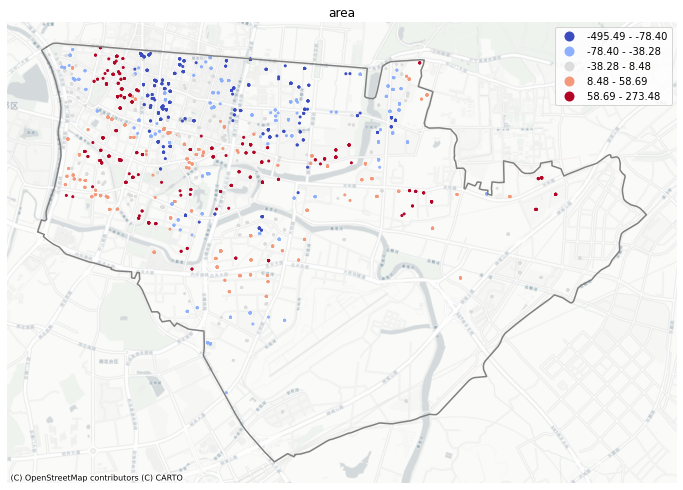

```python
drawMapNanjing(gwr_param, columns[1], 'coolwarm')
```

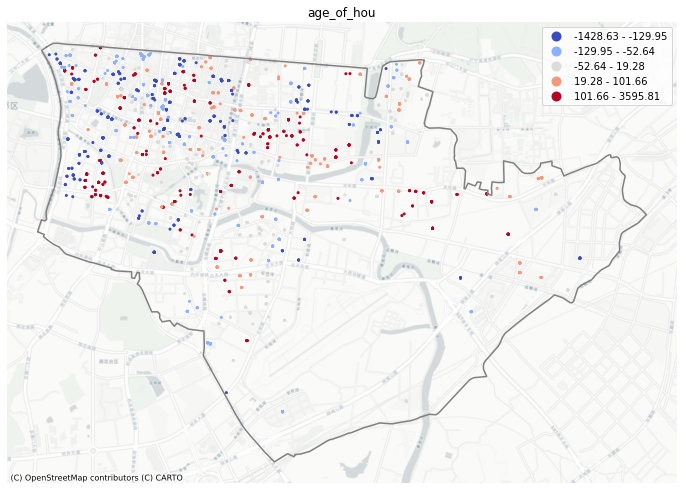

```python
drawMapNanjing(gwr_param, columns[2], 'coolwarm')
```

[figure not shown]

```python
drawMapNanjing(gwr_param, columns[3], 'coolwarm')
```

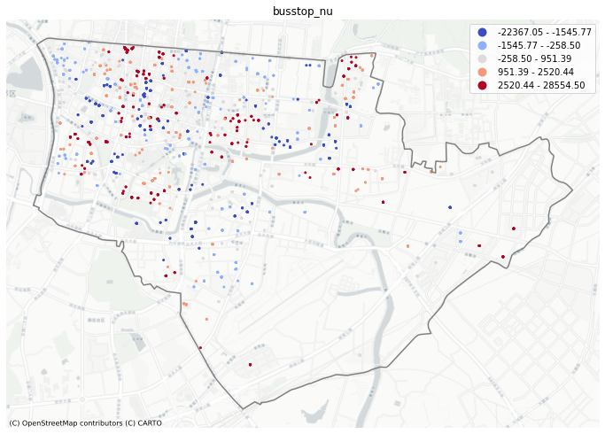

```python
drawMapNanjing(gwr_param, columns[4], 'coolwarm')
```

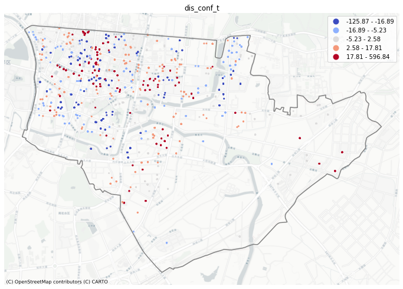

```python
drawMapNanjing(gwr_param, columns[5], 'coolwarm')
```